```r
loadmain()
#attach(main)
```

**John**: To facilitate our understanding of the data, I’ve begun running some elementary statistics on our dataset. These results are displayed here. I picture this is a rough draft for our methods and results section. This document is an R-notebook which is published online, and will automatically update when I rerun the underlying code. To improve readability, you might want to select “hide all code” above, which will collapse the R-code and show only the results.

# Data Exploration and Summary Statistics

## Mortality Data

### Construction of cross-time summary variables.

The 2016 elections represent cross-sectional data (one observation per county), but much of our other data, including data on mortality, varies by year. Therefore, we need to create variables which summarize such data across our sample time-frame. To this end, 3 variables were created for each county.

1. **[cause of death].12pdpy**, cause of death as a percentage of all deaths, per year since 2012.
2. **[cause of death].8pdpy**, cause of death as a percentage of all deaths, per year since 2008.
3. **[cause of death].disc95**, cause of death as a percentage of all deaths, per year since the beginning of the sample, weighing each subsequent year at 95% of the previous one.

Note that by using % of all deaths, rather than deaths per capita, we control for the fact that the overall death rate in different counties varies (prehaps due to age distribution). This is tantamount to using the “adjusted” death rates from the CDC, which, due to our method of extraction, are generally not available in our data. Unsuprisingly, these 3 variables are highly correlated:

```r
cor(select(main,matches('mort.*drugalc.*pdpy')),use='pairwise')
```

```
                             mort.ucd.drugalc.12.pdpy mort.ucd.drugalc.8.pdpy mort.ucd.drugalc.disc95.pdpy
mort.ucd.drugalc.12.pdpy                    1.0000000               0.9591966                    0.9428864
mort.ucd.drugalc.8.pdpy                     0.9591966               1.0000000                    0.9810659
mort.ucd.drugalc.disc95.pdpy                0.9428864               0.9810659                    1.0000000
```

### Correlations between type of deaths

```r
cor(select(main,matches('mort\\..*12\\.pdpy'),trumpstrnorm),use='pairwise')
```

```
                         mort.ucd.drugalc.12.pdpy mort.ucd.opioid.12.pdpy mort.ucd.suicide.12.pdpy
mort.ucd.drugalc.12.pdpy                1.0000000              0.55000745              0.488004263
mort.ucd.opioid.12.pdpy                 0.5500074              1.00000000              0.147783550
mort.ucd.suicide.12.pdpy                0.4880043              0.14778355              1.000000000
trumpstrnorm                            0.1498578              0.02087146             -0.004452776
                         trumpstrnorm
mort.ucd.drugalc.12.pdpy  0.149857818
mort.ucd.opioid.12.pdpy   0.020871463
mort.ucd.suicide.12.pdpy -0.004452776
trumpstrnorm              1.000000000
```

```r
cor(select(main,matches('mort\\..*8\\.pdpy'),trumpstrnorm),use='pairwise')
```

```
                        mort.ucd.drugalc.8.pdpy mort.ucd.opioid.8.pdpy mort.ucd.suicide.8.pdpy trumpstrnorm
mort.ucd.drugalc.8.pdpy               1.0000000             0.57208244            0.5790161392 0.1591001298
mort.ucd.opioid.8.pdpy                0.5720824             1.00000000            0.2296153389 0.0499870215
mort.ucd.suicide.8.pdpy               0.5790161             0.22961534            1.0000000000 0.0002447156
trumpstrnorm                          0.1591001             0.04998702            0.0002447156 1.0000000000
```

```r
cor(select(main,matches('mort\\..*disc95\\.pdpy'),trumpstrnorm),use='pairwise')
```

```
                             mort.ucd.drugalc.disc95.pdpy mort.ucd.opioid.disc95.pdpy
mort.ucd.drugalc.disc95.pdpy                    1.0000000                  0.60955859
mort.ucd.opioid.disc95.pdpy                     0.6095586                  1.00000000
mort.ucd.suicide.disc95.pdpy                    0.6555898                  0.27843418
trumpstrnorm                                    0.1709752                  0.06383137
                             mort.ucd.suicide.disc95.pdpy trumpstrnorm
mort.ucd.drugalc.disc95.pdpy                  0.655589830  0.170975158
mort.ucd.opioid.disc95.pdpy                   0.278434181  0.063831368
mort.ucd.suicide.disc95.pdpy                  1.000000000  0.009992866
trumpstrnorm                                  0.009992866  1.000000000
```

The drug/alcohol deaths and opioid deaths correlated, no suprise as the former contains the latter. Both are somewhat correlated to suicides. Note: Having established that the three summary statistics are similar, I will generally use the “.disc95” variables, as these make use of all of our data.

### Cross-sectional distribution of mortality by cause of death

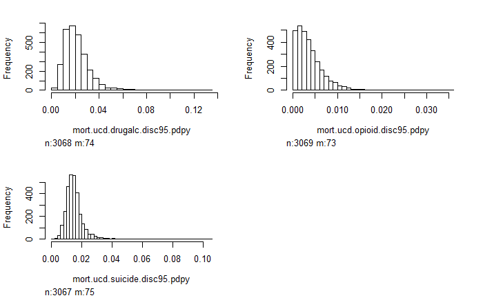

```r
hist(select(main,matches('mort\\..*disc95\\.pdpy')))
```

These look pretty similar to each other; roughly log-normal with opiod mortality censored at zero. If we plot deaths on a map, a striking pattern emerges:

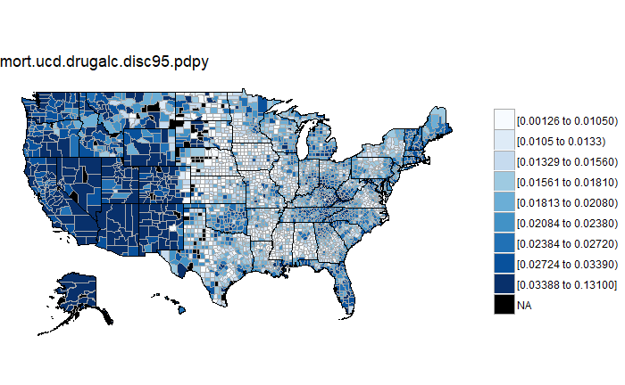

```r
suppressWarnings(map.cnty(main,mort.ucd.drugalc.disc95.pdpy,9))
```

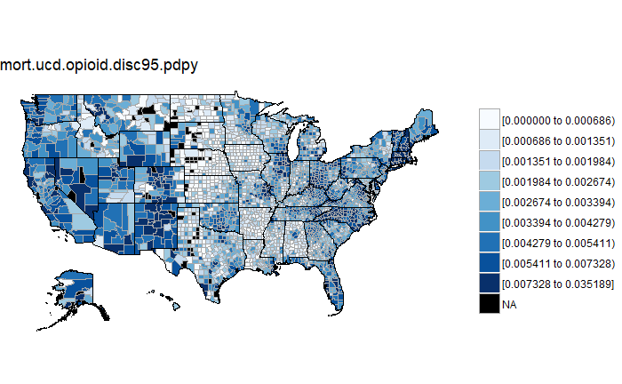

```r
suppressWarnings(map.cnty(main,mort.ucd.opioid.disc95.pdpy,9))
```

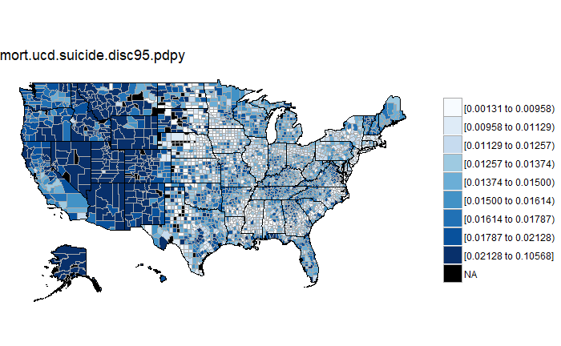

```r
suppressWarnings(map.cnty(main,mort.ucd.suicide.disc95.pdpy,9))
```

The western united states seems to have much higher levels of drug/alcohol and suicide mortality. The effect is less striking with opioid deaths. This pattern is of significance to us, since support for Donald Trump during the primaries also tended to be higher in the west.

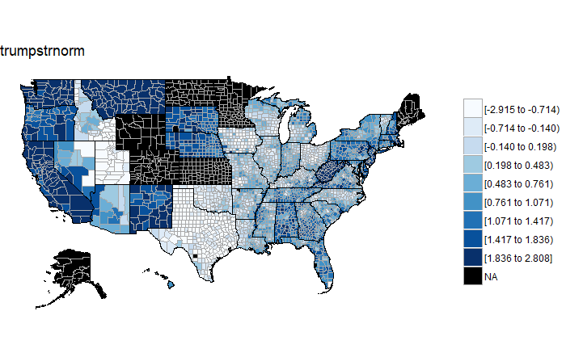

```r
suppressWarnings(map.cnty(main,trumpstrnorm,9))
```

Other researchers have noticed this pattern. For example, [this study](https://www.rwjf.org/en/library/articles-and-news/2013/06/solving-the-riddle-of-the-u-s--suicide-belt.html) contends that the phenomenon has to do with ‘residential stability’; i.e., how often people are moving in and out of the given county.

```r
cor(main$mort.ucd.drugalc.12.pdpy, main$demo.popdense,use='pairwise')
```

```
[1] 0.07846055
```

```r
# suppressWarnings(map.cnty(main,mort.ucd.suicide.disc95.pdpy,9))
# main[,demo.popdenseinv := 1/demo.popdense]
# suppressWarnings(map.cnty(main,demo.popdenseinv,9))
```

```r
cor(select(main,matches('mort\\..*disc95\\.pdpy'),race.na.p),use='pairwise')
```

```
                             mort.ucd.drugalc.disc95.pdpy mort.ucd.opioid.disc95.pdpy
mort.ucd.drugalc.disc95.pdpy                    1.0000000                 0.609558586
mort.ucd.opioid.disc95.pdpy                     0.6095586                 1.000000000
mort.ucd.suicide.disc95.pdpy                    0.6555898                 0.278434181
race.na.p                                       0.4578013                 0.004228295
                             mort.ucd.suicide.disc95.pdpy   race.na.p
mort.ucd.drugalc.disc95.pdpy                    0.6555898 0.457801315
mort.ucd.opioid.disc95.pdpy                     0.2784342 0.004228295
mort.ucd.suicide.disc95.pdpy                    1.0000000 0.416519067
race.na.p                                       0.4165191 1.000000000
```

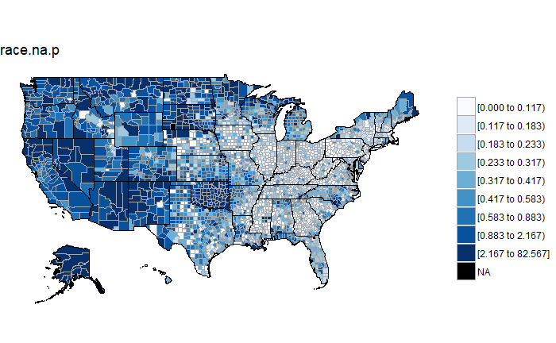

```r
suppressWarnings(map.cnty(main,race.na.p,9))
```

## Exploring the political data

### Our key political indicators

Our data contains many measures of electoral performance, but we focus on three.

1. **trumpstrnorm**: Normalized trump margin of victory in the primaries. This is the variable which you constructed, John. In counties where trump won, it’s equal to the percent by which he bested the second strongest GOP candidate. In counties which he lost, it is negative, and equal to the difference between him and the winning candidate. The “normalized” refers to the fact that this number was then multipled by the total number of candidates, since winning by 50% with 2 candidates is analogous to winning by 25% with 4 candidates.
2. **dr.pmarg**: The democratic margin of victory in a given election year.
3. **pmarg.dif**: The difference in the democractic margin of victory between 2016 and another election year. For example, pmarg.dif12 = .05 means democrats won by 5% more in 2016, as compared to 2012.

These three variables are mapped below.

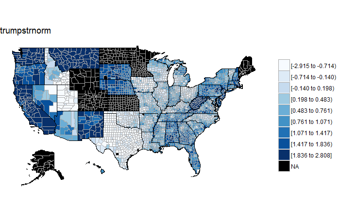

```r
suppressWarnings(map.cnty(main,trumpstrnorm,9))
```

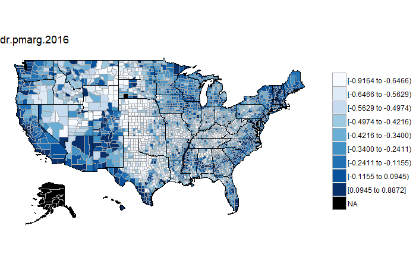

```r
suppressWarnings(map.cnty(main,dr.pmarg.2016,9))
```

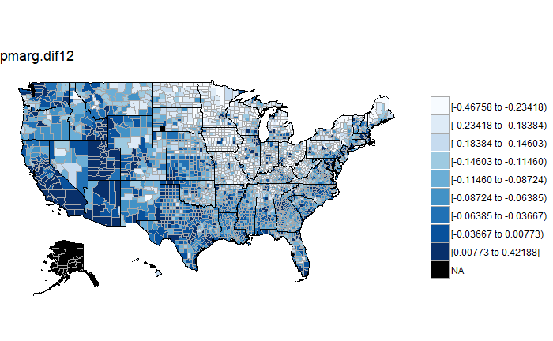

```r
suppressWarnings(map.cnty(main,pmarg.dif12,9))
```

### Distrubution and Correlations

Next, I plot histograms of vote percentages for four candidates; no real suprises where; more popular candidates seem to have a greater number of counties counties where they truly dominate (more than 75% share of vote, let’s say).

```
click left mouse button to proceed
```

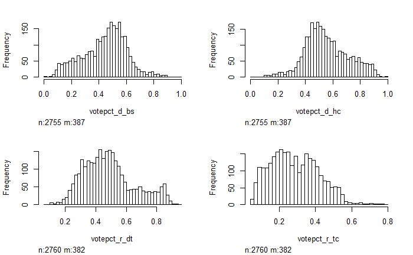

```r
hist(select(main,matches('votepct_d_bs'),votepct_d_hc,votepct_r_dt,votepct_r_tc))
```

Finally, let’s consider how these varaibles are related by examining their correlations with one another. Note the negative correlation between trumpstr and pmarg.dif12/08. Counties were trump won the primaries are also counties the GOP carried strongly in the general elections, when compared to previous election cycles. Also note that the correlation between Trump and Bernie’s primary preformance was actually positive.

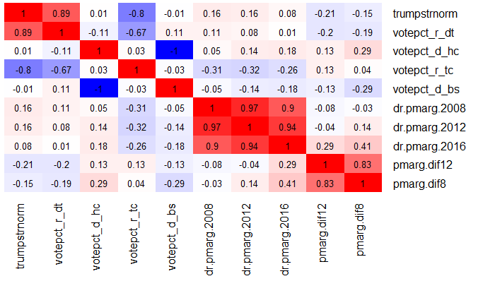

```r
t.cor = cor(select(main,trumpstrnorm,votepct_r_dt,votepct_d_hc,votepct_r_tc,votepct_d_bs,matches('dr.pmarg'),matches('pmarg.dif')),use='pairwise')
require('colorspace')
require('gplots')
cols2 = diverge_hsv(100,alpha=1)
t.cor.round = round(t.cor, digits = 2)
heatmap.2( t.cor, Rowv=F, Colv=F, dendrogram='none', key=F, col = cols2,symm=T,trace='none',lwid=c(.01,.99),lhei=c(.01,.99),margins = c(10,10),cellnote=t.cor.round,notecol='black')
```

## Exploring the economic crash variables

## Exploring the other variables